# wineQuality

KennethShang

2017年4月25日

# WineQuality Exploration by Chris Saden

# Univariate Plots Section

```
## [1] 1599   13
```

```
## 'data.frame':    1599 obs. of  13 variables:
##  $ X                   : int  1 2 3 4 5 6 7 8 9 10 ...
##  $ fixed.acidity       : num  7.4 7.8 7.8 11.2 7.4 7.4 7.9 7.3 7.8 7.5 ...
##  $ volatile.acidity    : num  0.7 0.88 0.76 0.28 0.7 0.66 0.6 0.65 0.58 0.5 ...
##  $ citric.acid         : num  0 0 0.04 0.56 0 0 0.06 0 0.02 0.36 ...
##  $ residual.sugar      : num  1.9 2.6 2.3 1.9 1.9 1.8 1.6 1.2 2 6.1 ...
##  $ chlorides           : num  0.076 0.098 0.092 0.075 0.076 0.075 0.069 0.065 0.073 0.071 ...
##  $ free.sulfur.dioxide : num  11 25 15 17 11 13 15 15 9 17 ...
##  $ total.sulfur.dioxide: num  34 67 54 60 34 40 59 21 18 102 ...
##  $ density             : num  0.998 0.997 0.997 0.998 0.998 ...
##  $ pH                  : num  3.51 3.2 3.26 3.16 3.51 3.51 3.3 3.39 3.36 3.35 ...
##  $ sulphates           : num  0.56 0.68 0.65 0.58 0.56 0.56 0.46 0.47 0.57 0.8 ...
##  $ alcohol             : num  9.4 9.8 9.8 9.8 9.4 9.4 9.4 10 9.5 10.5 ...
##  $ quality             : int  5 5 5 6 5 5 5 7 7 5 ...
```

```
##        X          fixed.acidity   volatile.acidity  citric.acid
##  Min.   :   1.0   Min.   : 4.60   Min.   :0.1200   Min.   :0.000
##  1st Qu.: 400.5   1st Qu.: 7.10   1st Qu.:0.3900   1st Qu.:0.090
##  Median : 800.0   Median : 7.90   Median :0.5200   Median :0.260
##  Mean   : 800.0   Mean   : 8.32   Mean   :0.5278   Mean   :0.271
##  3rd Qu.:1199.5   3rd Qu.: 9.20   3rd Qu.:0.6400   3rd Qu.:0.420
##  Max.   :1599.0   Max.   :15.90   Max.   :1.5800   Max.   :1.000
##  residual.sugar     chlorides       free.sulfur.dioxide
##  Min.   : 0.900   Min.   :0.01200   Min.   : 1.00
##  1st Qu.: 1.900   1st Qu.:0.07000   1st Qu.: 7.00
##  Median : 2.200   Median :0.07900   Median :14.00
##  Mean   : 2.539   Mean   :0.08747   Mean   :15.87
##  3rd Qu.: 2.600   3rd Qu.:0.09000   3rd Qu.:21.00
##  Max.   :15.500   Max.   :0.61100   Max.   :72.00
##  total.sulfur.dioxide    density             pH          sulphates
##  Min.   :  6.00       Min.   :0.9901   Min.   :2.740   Min.   :0.3300
##  1st Qu.: 22.00       1st Qu.:0.9956   1st Qu.:3.210   1st Qu.:0.5500
##  Median : 38.00       Median :0.9968   Median :3.310   Median :0.6200
##  Mean   : 46.47       Mean   :0.9967   Mean   :3.311   Mean   :0.6581
##  3rd Qu.: 62.00       3rd Qu.:0.9978   3rd Qu.:3.400   3rd Qu.:0.7300
##  Max.   :289.00       Max.   :1.0037   Max.   :4.010   Max.   :2.0000
##     alcohol         quality
##  Min.   : 8.40   Min.   :3.000
##  1st Qu.: 9.50   1st Qu.:5.000
##  Median :10.20   Median :6.000
##  Mean   :10.42   Mean   :5.636
##  3rd Qu.:11.10   3rd Qu.:6.000
##  Max.   :14.90   Max.   :8.000
```

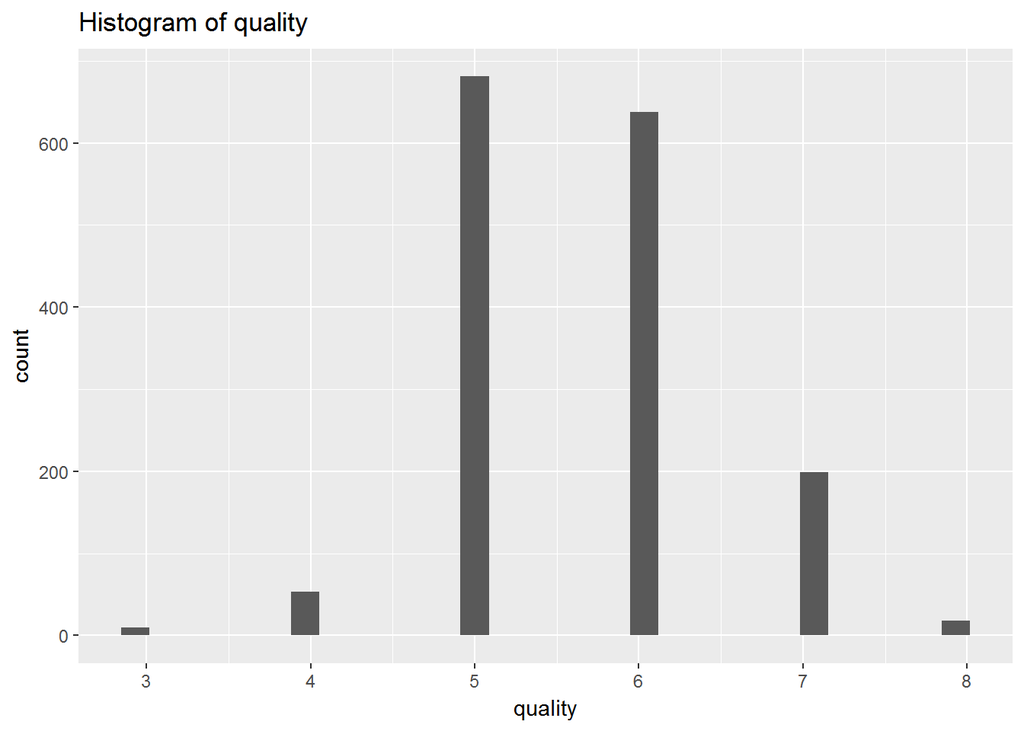

The distribution of the wine quality appears normal. This Histogram also indicate that the quality of the wine is a discrete variable and most of the quality given by the experts are 5 and 6.

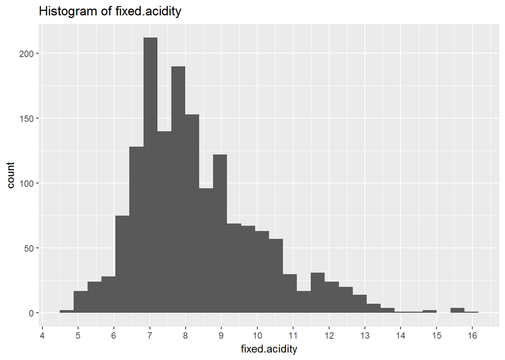

Most of the red wine have a value of fixed.acidity between 6 and 9

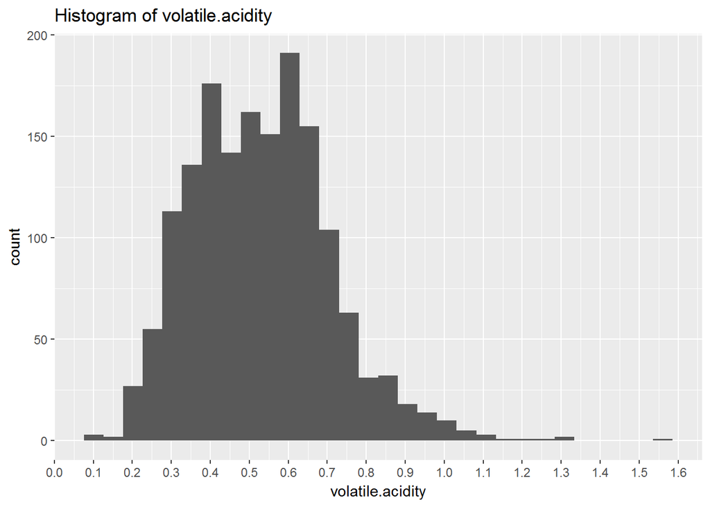

Most of the red wine have a value of volatile.acidity between 0.3 and 0.7

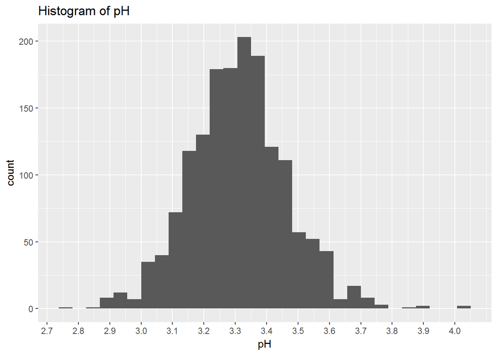

Most of the red wine have a value of PH between 3.1 and 3.6

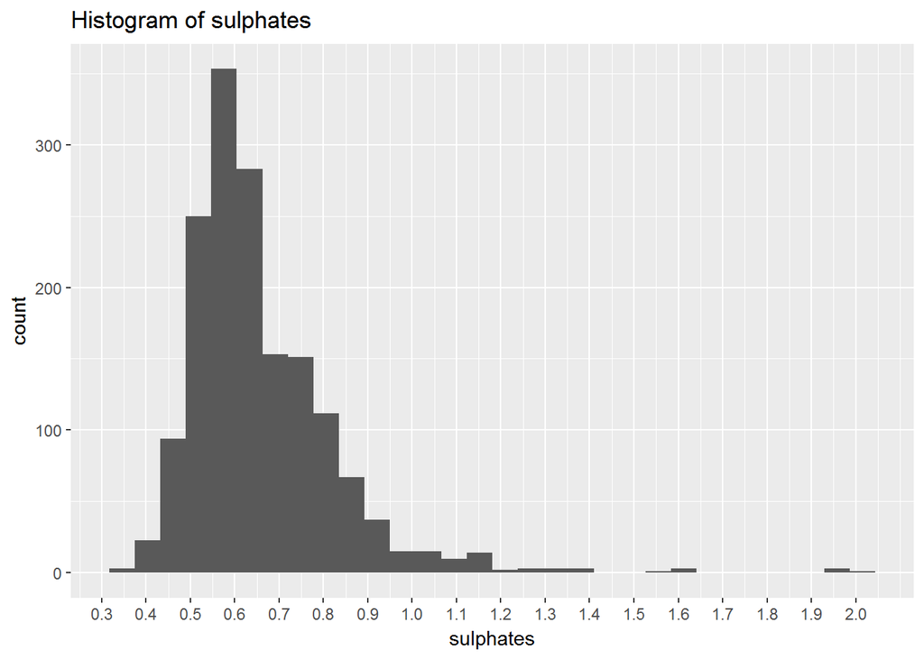

Most of the red wine have a value of sulphates between 0.5 and 0.8

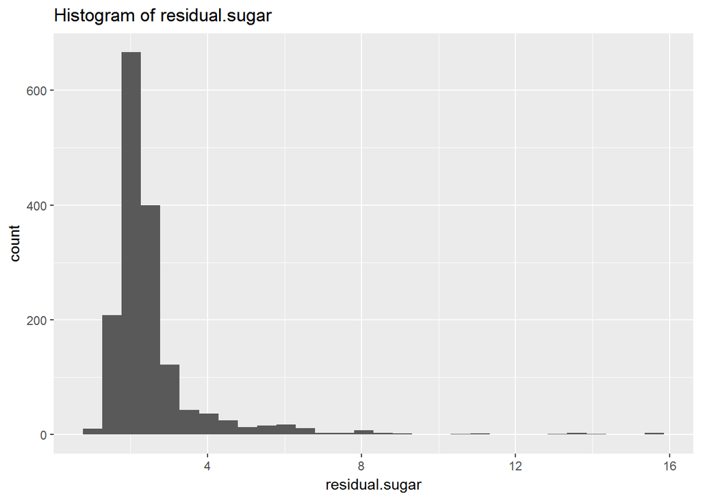

There are some kinds of red wine which contains a lot of sugar or sulphates and maybe they are outliers. So we change the scale of the residual.sugar and sulphates to replot the diagrams.

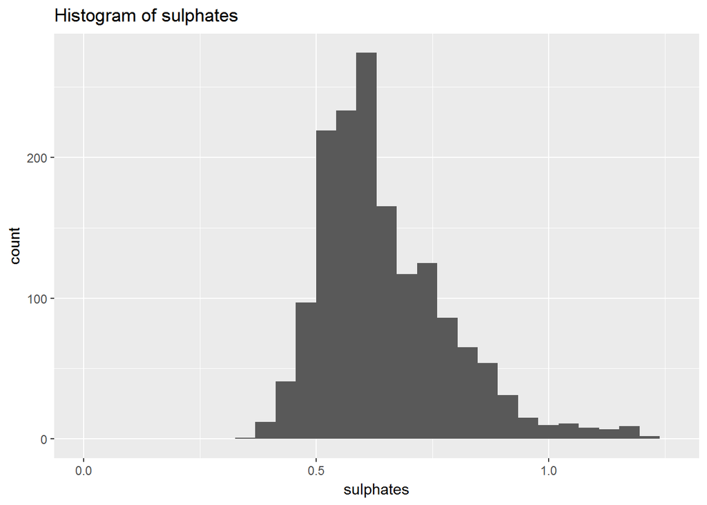

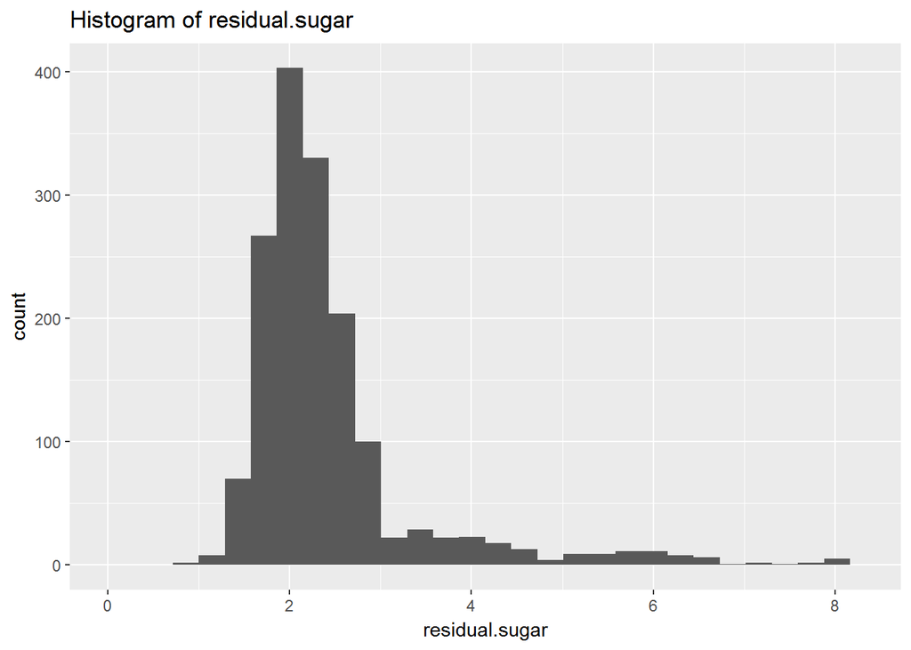

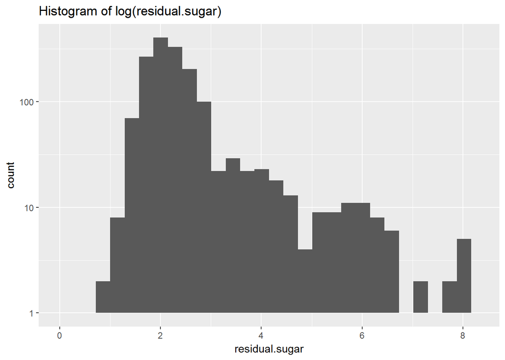

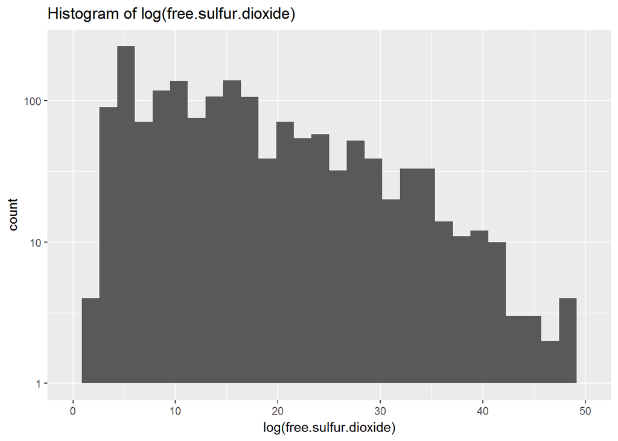

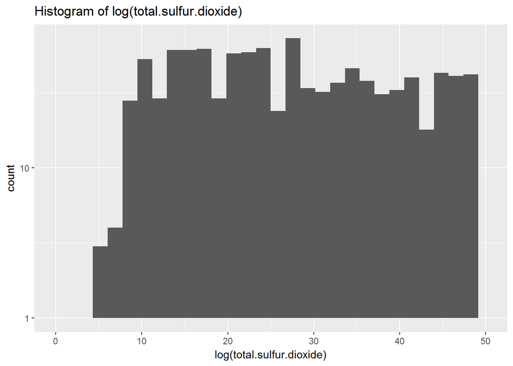

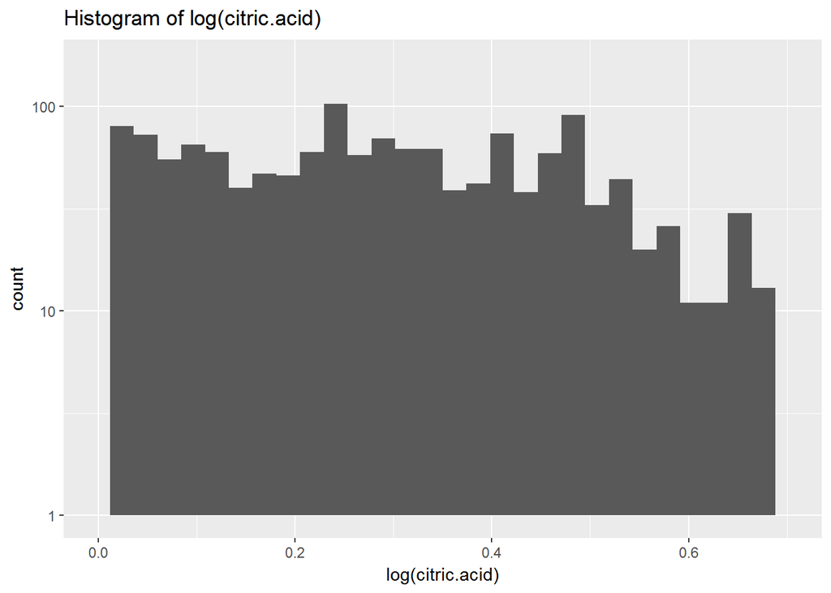

It seems that there are no obvious deviation of citric.acid, free.sulfur.dioxide and total.sulfur.dioxide.

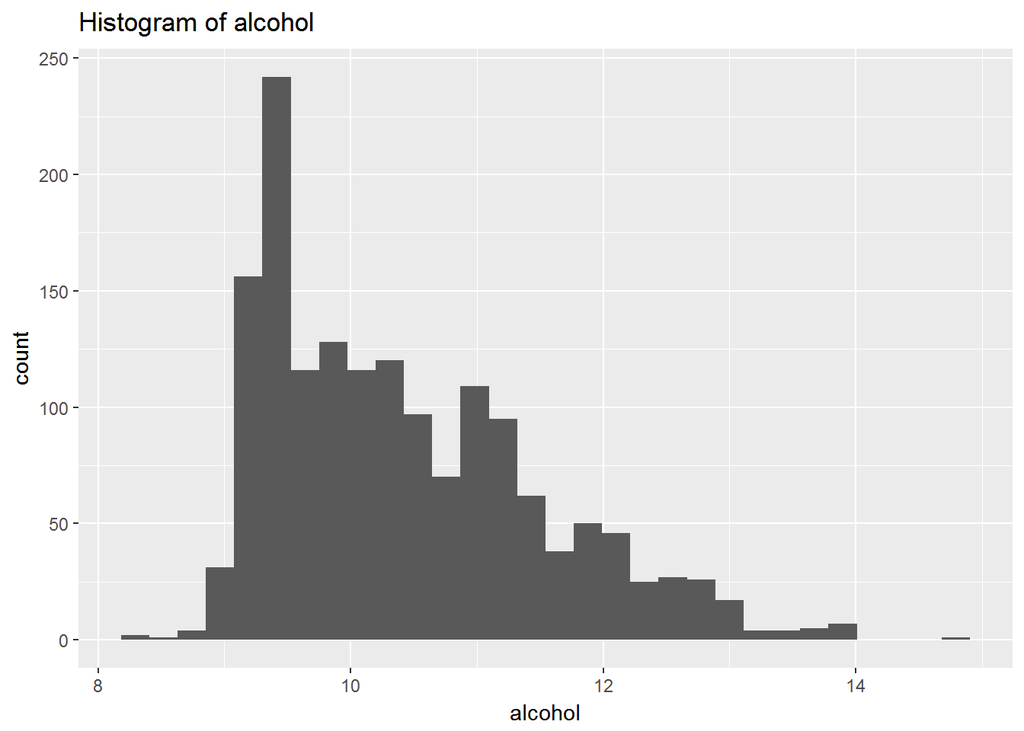

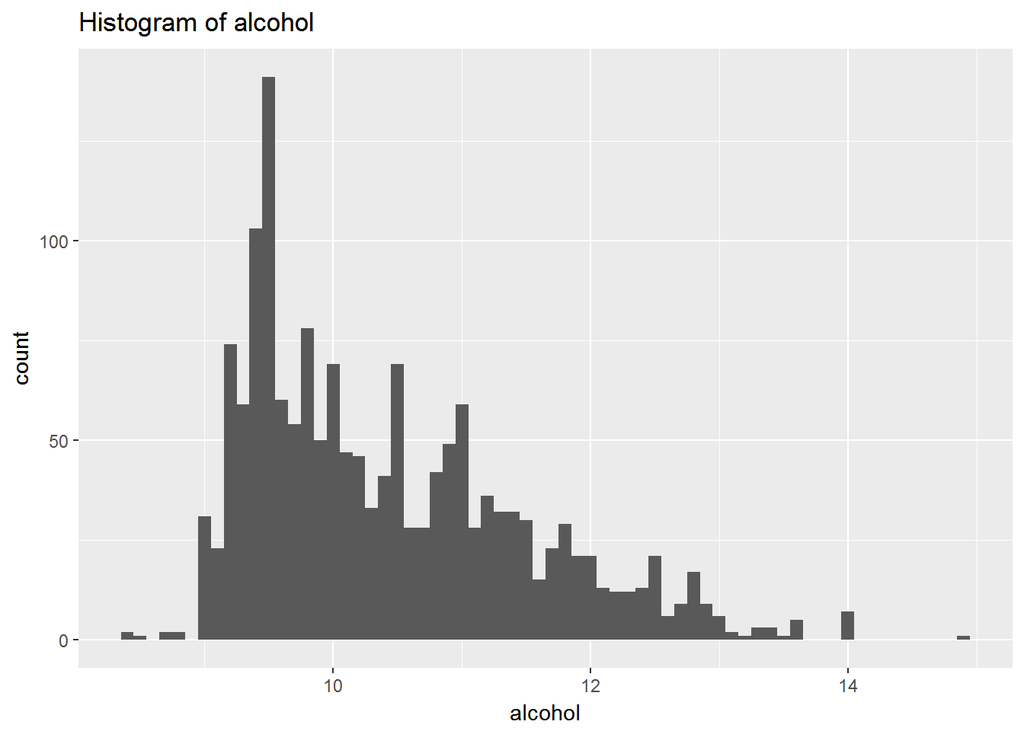

```
##    Min. 1st Qu.  Median    Mean 3rd Qu.    Max.
##    8.40    9.50   10.20   10.42   11.10   14.90
```

The highest alcohol content of the red wine in this dataset is 14.9 and the lowest is 8.4.

# Univariate Analysis

### What is the structure of your dataset?

(worst) —————-> (best)

*quality*: 0, 1, 2, 3, 4, 5, 6, 7, 8, 9, 10

### What is/are the main feature(s) of interest in your dataset?

The main features in the data set maybe quality and alcohol. I’d like to determine which features are best for predicting the quality of the red wine. I suspect alcohol and some combination of the other variables can be used to build a predictive model to red wine quality.

### What other features in the dataset do you think will help support your investigation into your feature(s) of interest?

fixed.acidity, volatile.acidity, citric.acid, chlorides, density, sulphates and alcohol likely contribute to the quality of red wine. I think alcohol and volatile.acidity probably contribute most to the quality.

### Of the features you investigated, were there any unusual distributions? Did you perform any operations on the data to tidy, adjust, or change the form of the data? If so, why did you do this?

When i investigated into the residual.sugar and sulphates, i found that there maybe some outliers in the dataset. So I use the scale_x_continus() function to remain 0.99 quantile and replot it which seems better.

# Bivariate Plots Section

```
##                  fixed.acidity volatile.acidity citric.acid chlorides
## fixed.acidity             1.00            -0.26        0.67      0.09
## volatile.acidity         -0.26             1.00       -0.55      0.06
## citric.acid               0.67            -0.55        1.00      0.20
## chlorides                 0.09             0.06        0.20      1.00
## density                   0.67             0.02        0.36      0.20
## sulphates                 0.18            -0.26        0.31      0.37
## alcohol                  -0.06            -0.20        0.11     -0.22
## quality                   0.12            -0.39        0.23     -0.13
##                  density sulphates alcohol quality
## fixed.acidity       0.67      0.18   -0.06    0.12
## volatile.acidity    0.02     -0.26   -0.20   -0.39
## citric.acid         0.36      0.31    0.11    0.23
## chlorides           0.20      0.37   -0.22   -0.13
## density             1.00      0.15   -0.50   -0.17
## sulphates           0.15      1.00    0.09    0.25
## alcohol            -0.50      0.09    1.00    0.48
## quality            -0.17      0.25    0.48    1.00
```

The quality of a red wine tend to correlate with each other. And the Qulity correlates strongly with alcohol and volatile.acidity. The higher alcohol content by the red wine the better quality the red wine will be and the lower volatile.acidity the red wine contain the better quality the red wine will get.

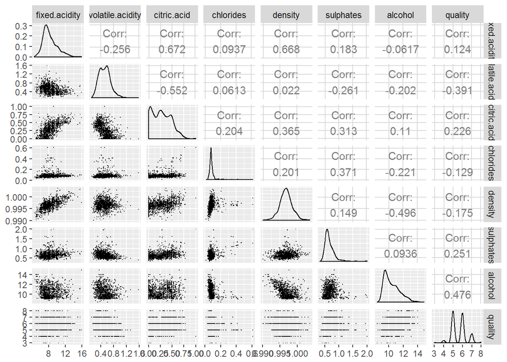

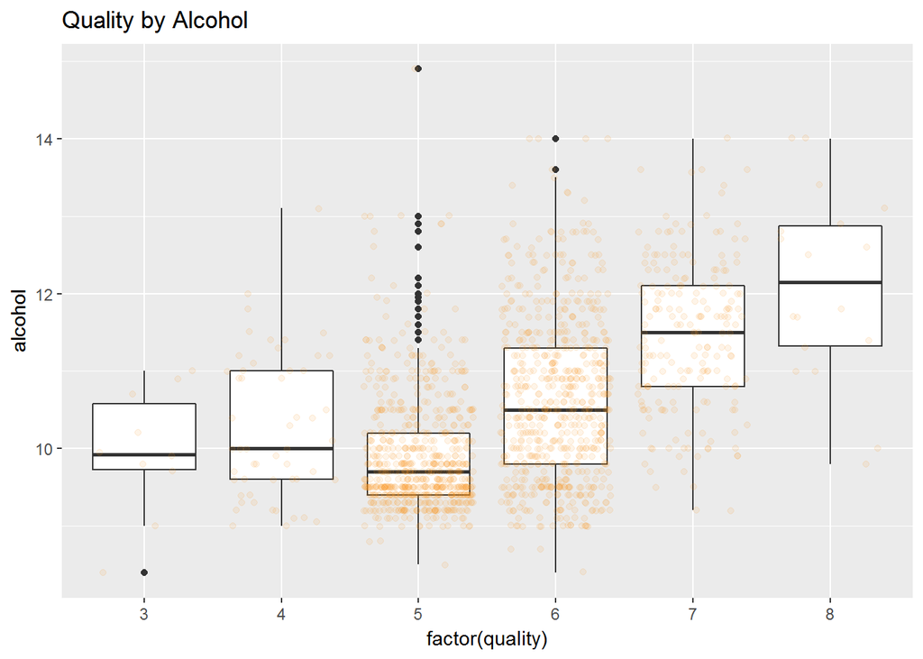

```
## WQ$quality: 3
##    Min. 1st Qu.  Median    Mean 3rd Qu.    Max.
##   8.400   9.725   9.925   9.955  10.580  11.000
## --------------------------------------------------------
## WQ$quality: 4
##    Min. 1st Qu.  Median    Mean 3rd Qu.    Max.
##    9.00    9.60   10.00   10.27   11.00   13.10
## --------------------------------------------------------
## WQ$quality: 5
##    Min. 1st Qu.  Median    Mean 3rd Qu.    Max.
##     8.5     9.4     9.7     9.9    10.2    14.9
## --------------------------------------------------------
## WQ$quality: 6
##    Min. 1st Qu.  Median    Mean 3rd Qu.    Max.
##    8.40    9.80   10.50   10.63   11.30   14.00
## --------------------------------------------------------
## WQ$quality: 7
##    Min. 1st Qu.  Median    Mean 3rd Qu.    Max.
##    9.20   10.80   11.50   11.47   12.10   14.00
## --------------------------------------------------------
## WQ$quality: 8
##    Min. 1st Qu.  Median    Mean 3rd Qu.    Max.
##    9.80   11.32   12.15   12.09   12.88   14.00
```

As the quality increases, the value of the alcohol increases. We still see when the quality is 5, there is a strange value that the median of the alcohol is less than when the quality is 4 and 6. Beside, in the diagram shown before, we can see that more data concentrated to quality 5 and 6.

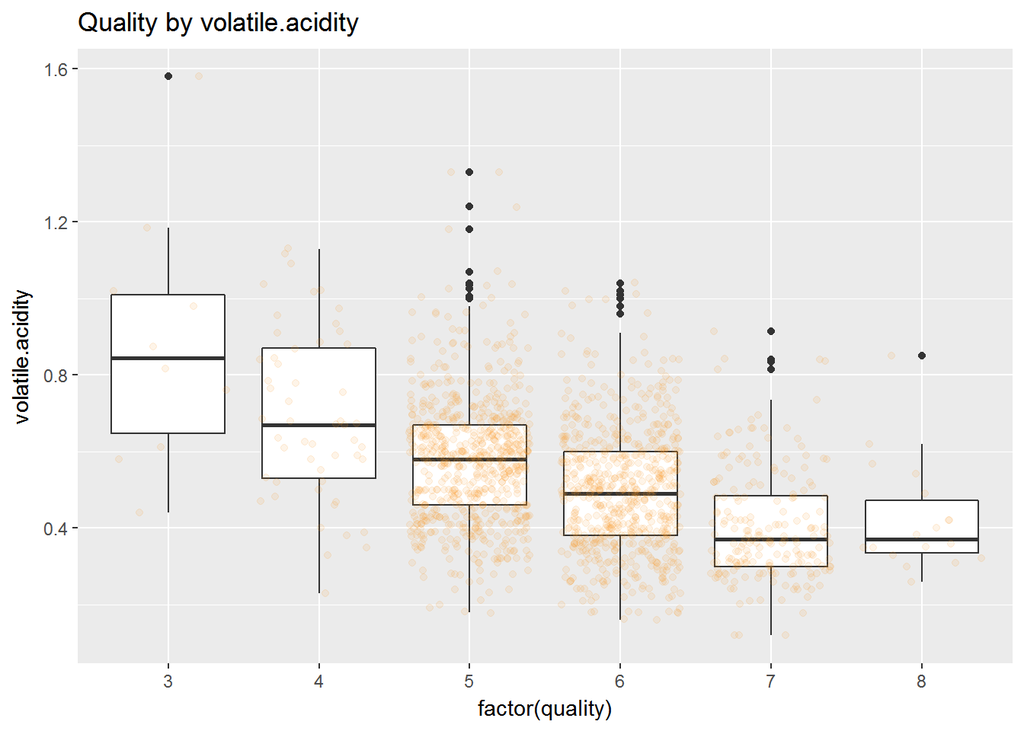

```
## WQ$quality: 3
##    Min. 1st Qu.  Median    Mean 3rd Qu.    Max.
##  0.4400  0.6475  0.8450  0.8845  1.0100  1.5800
## --------------------------------------------------------
## WQ$quality: 4
##    Min. 1st Qu.  Median    Mean 3rd Qu.    Max.
##   0.230   0.530   0.670   0.694   0.870   1.130
## --------------------------------------------------------
## WQ$quality: 5
##    Min. 1st Qu.  Median    Mean 3rd Qu.    Max.
##   0.180   0.460   0.580   0.577   0.670   1.330
## --------------------------------------------------------
## WQ$quality: 6
##    Min. 1st Qu.  Median    Mean 3rd Qu.    Max.
##  0.1600  0.3800  0.4900  0.4975  0.6000  1.0400
## --------------------------------------------------------
## WQ$quality: 7
##    Min. 1st Qu.  Median    Mean 3rd Qu.    Max.
##  0.1200  0.3000  0.3700  0.4039  0.4850  0.9150
## --------------------------------------------------------
## WQ$quality: 8
##    Min. 1st Qu.  Median    Mean 3rd Qu.    Max.
##  0.2600  0.3350  0.3700  0.4233  0.4725  0.8500
```

As the quality increases, the value of the volatile.acidity decreases. it looks like most of the red wine with good quality has a low volatile.acidity value.

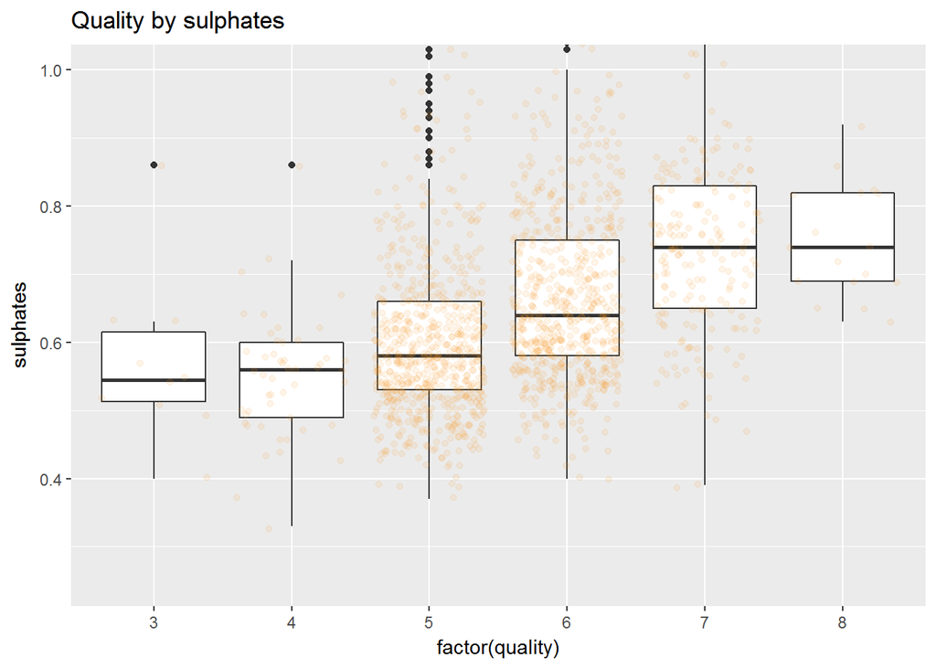

```
## WQ$quality: 3
##    Min. 1st Qu.  Median    Mean 3rd Qu.    Max.
##  0.4000  0.5125  0.5450  0.5700  0.6150  0.8600
## --------------------------------------------------------
## WQ$quality: 4
##    Min. 1st Qu.  Median    Mean 3rd Qu.    Max.
##  0.3300  0.4900  0.5600  0.5964  0.6000  2.0000
## --------------------------------------------------------
## WQ$quality: 5
##    Min. 1st Qu.  Median    Mean 3rd Qu.    Max.
##   0.370   0.530   0.580   0.621   0.660   1.980
## --------------------------------------------------------
## WQ$quality: 6
##    Min. 1st Qu.  Median    Mean 3rd Qu.    Max.
##  0.4000  0.5800  0.6400  0.6753  0.7500  1.9500
## --------------------------------------------------------
## WQ$quality: 7
##    Min. 1st Qu.  Median    Mean 3rd Qu.    Max.
##  0.3900  0.6500  0.7400  0.7413  0.8300  1.3600
## --------------------------------------------------------
## WQ$quality: 8
##    Min. 1st Qu.  Median    Mean 3rd Qu.    Max.
##  0.6300  0.6900  0.7400  0.7678  0.8200  1.1000
```

### Talk about some of the relationships you observed in this part of the investigation. How did the feature(s) of interest vary with other features in the dataset?

As the value of alcohol, sulphates increases, the quality of the red wine increases, and with the volatile.acidity decrase the quality of the red wine increases.

A good quality red wine have the lowest volatile.acidity and highest sulphates and alcohol value.

### Did you observe any interesting relationships between the other features (not the main feature(s) of interest)?

I find that relationship between fixed.acidity and density appears to be linear.

### What was the strongest relationship you found?

The quality of a red wine is positively and strongly correlated with alcohol. The volatile.acidity also correlated with the quality and is negitively correlated. Either volatile.acidity and alcohol could be used in a model to predict the quality of the red wine.

# Multivariate Plots Section

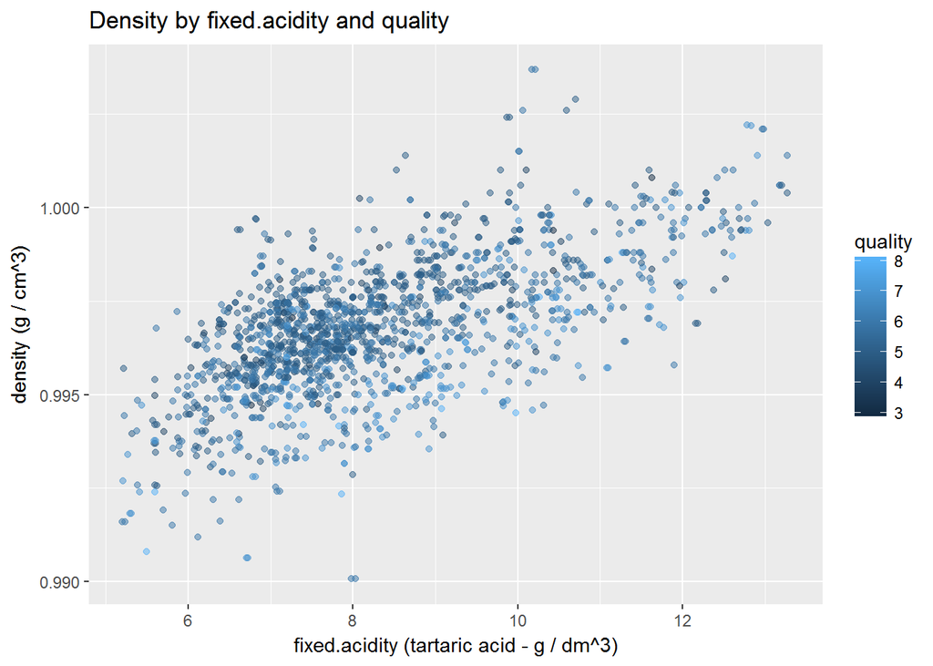

It seems that at a same fixed.acidity value, higher quality the red wine have lower density it will be. # Build a liner model to predict the quality of the red wine

```
##
## Calls:
## m1: lm(formula = quality ~ alcohol, data = sub_WQ)
## m2: lm(formula = quality ~ alcohol + fixed.acidity, data = sub_WQ)
## m3: lm(formula = quality ~ alcohol + fixed.acidity + sulphates, data = sub_WQ)
##
## ===================================================
##                      m1         m2         m3
## ---------------------------------------------------
##   (Intercept)      1.875***   1.206***   0.913***
##                   (0.175)    (0.196)    (0.195)
##   alcohol          0.361***   0.368***   0.353***
##                   (0.017)    (0.016)    (0.016)
##   fixed.acidity               0.071***   0.055***
##                              (0.010)    (0.010)
##   sulphates                              0.886***
##                                         (0.103)
## ---------------------------------------------------
##   R-squared            0.2        0.3        0.3
##   adj. R-squared       0.2        0.2        0.3
##   sigma                0.7        0.7        0.7
##   F                  468.3      266.5      210.3
##   p                    0.0        0.0        0.0
##   Log-likelihood   -1721.1    -1696.2    -1660.2
##   Deviance           805.9      781.2      746.8
##   AIC               3448.1     3400.5     3330.4
##   BIC               3464.2     3422.0     3357.2
##   N                 1599       1599       1599
## ===================================================
```

### Talk about some of the relationships you observed in this part of the investigation. Were there features that strengthened each other in terms of looking at your feature(s) of interest?

Red wine with better quality tend to be lower density holding fixed.acidity constant. This trend is not as clear when looking at quality vs density and fixed.acidity, but the trend is still present.

### Were there any interesting or surprising interactions between features?

Most of the data concentrate to the left side of the “Density by fixed.acidity and quality” graph wich means maybe our dataset is a small sample of the original dataset and isn’t well sampling.

### OPTIONAL: Did you create any models with your dataset? Discuss the strengths and limitations of your model.

Yes, I created a linear model starting from the quality and the alcohol.

But it seems it don’t match well with the dataset for the variables in the linear model account for 30% of the variance in the quality of wine quality.

# Final Plots and Summary

### Plot One

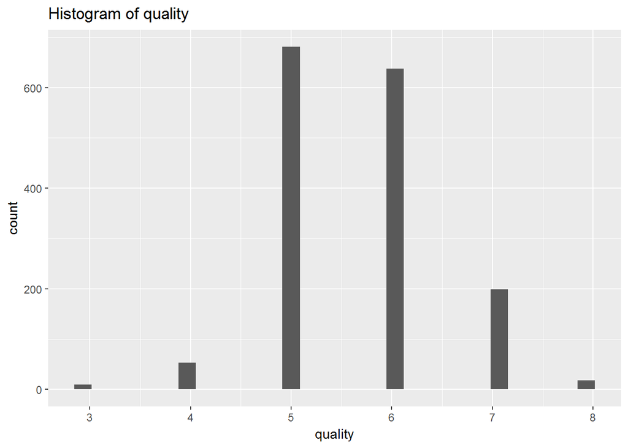

### Description One

The distribution of the wine quality appears normal. This Histogram also indicate that the quality of the wine is a discrete variable and most of the quality given by the experts are 5 and 6.

### Plot Two

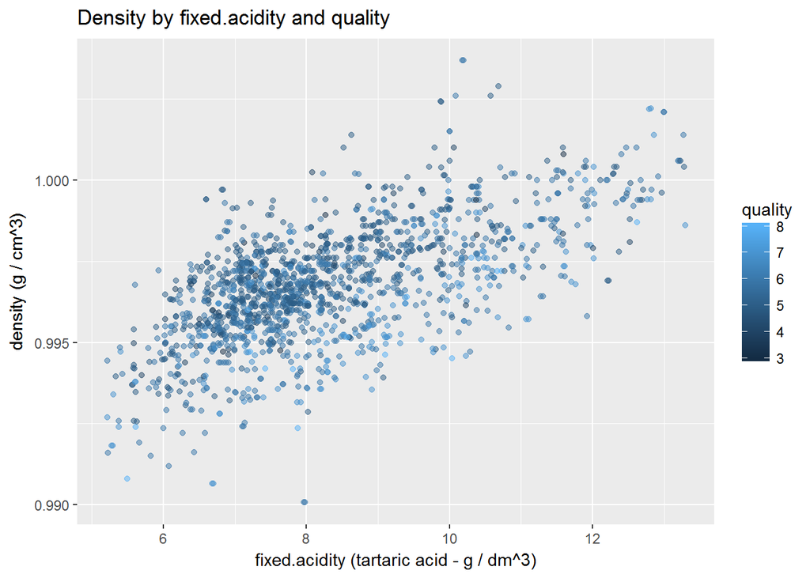

### Description Two

It seems that at a same fixed.acidity value, higher quality the red wine have lower density it will be.

### Plot Three

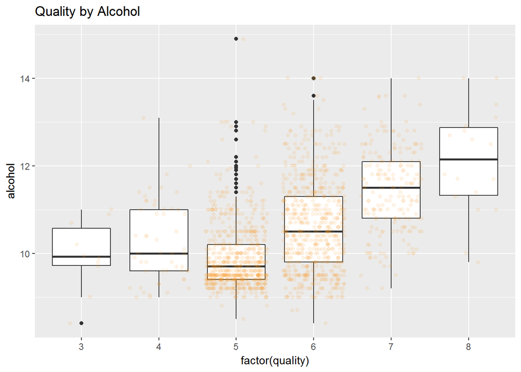

### Conclusion

# Reflection

None